# Ch 4. Exercises

Author

Daniela Palleschi

# Set options

```r
# set condition so that when we knit a single child Rmd we also get the references for just that section
## the parent.Rmd creates 'knit_type' to 'parent'; if this is a child knit then 'knit_type' does not exist yet

# if 'parent_knit' exists, then it was created in 'parent.Rmd' and this is a parent knit, so keep it unchanged, otherwise call it 'child'
knit_type = ifelse(exists("knit_type"),knit_type,"chapter")
```

```r
# set global knit options
knitr::opts_chunk$set(echo = T,
                      eval = T,
                      error = F,
                      warning = F,
                      message = F,
                      cache = T)

# suppress scientific notation
options(scipen=999)

# list of required packages
packages <- c( #"SIN", # this package was removed from the CRAN repository
               "MASS", "dplyr", "tidyr", "purrr", "extraDistr", "ggplot2", "loo", "bridgesampling", "brms", "bayesplot", "tictoc", "hypr", "bcogsci", "papaja", "grid", "kableExtra", "gridExtra", "lme4", "cowplot", "pdftools", "cmdstanr", "rootSolve", "rstan"
  )

# NB: if you haven't already installed bcogsci through devtools, it won't be loaded
## Now load or install & load all
package.check <- lapply(
  packages,
  FUN = function(x) {
    if (!require(x, character.only = TRUE)) {
      install.packages(x, dependencies = TRUE)
      library(x, character.only = TRUE)
    }
  }
)

# this is also required, taken from the textbook

## Save compiled models:
rstan_options(auto_write = FALSE)
## Parallelize the chains using all the cores:
options(mc.cores = parallel::detectCores())
# To solve some conflicts between packages
select <- dplyr::select
extract <- rstan::extract
```

# 1 Chapter 4

## Exercise 4.1 - A simple linear regression: Power posing and testosterone.

Load the following data set:

```r
data("df_powerpose")
head(df_powerpose)
```

```
  id hptreat female age testm1  testm2
2 29    High   Male  19 38.725  62.375
3 30     Low Female  20 32.770  29.235
4 31    High Female  20 32.320  27.510
5 32     Low Female  18 17.995  28.655
7 34     Low Female  21 73.580  44.670
8 35    High Female  20 80.695 105.485
```

The data set, which was originally published in Carney, Cuddy, and Yap (2010) but released in modified form by Fosse (2016), shows the testosterone levels of 39 different individuals, before and after treatment, where treatment refers to each individual being assigned to a high power pose or a low power pose. In the original paper by Carney, Cuddy, and Yap (2010), the unit given for testosterone measurement (estimated from saliva samples) was picograms per milliliter (pg/ml). One picogram per milliliter is 0.001 nanogram per milliliter (ng/ml).

The research hypothesis is that on average, assigning a subject a high power pose vs. a low power pose will lead to higher testosterone levels after treatment. Assuming that you know nothing about normal ranges of testosterone using salivary measurement, choose an appropriate Cauchy prior (e.g., $Cauchy(0,2.5)$ for the target parameter(s).

Investigate this claim using a linear model and the default priors of `brms.` You’ll need to estimate the effect of a new variable that encodes the change in testosterone.

### My work

- DV: change in testosterone levels (continuous, `testm2`-`testm1`)
- IV: `hptreat` (binomial: high/low)

```r
# create change variable
df_powerpose <- df_powerpose %>%
  mutate(change = testm2-testm1)
head(df_powerpose)
```

```
  id hptreat female age testm1  testm2     change
2 29    High   Male  19 38.725  62.375  23.650002
3 30     Low Female  20 32.770  29.235  -3.534999
4 31    High Female  20 32.320  27.510  -4.810000
5 32     Low Female  18 17.995  28.655  10.660000
7 34     Low Female  21 73.580  44.670 -28.910004
8 35    High Female  20 80.695 105.485  24.790000
```

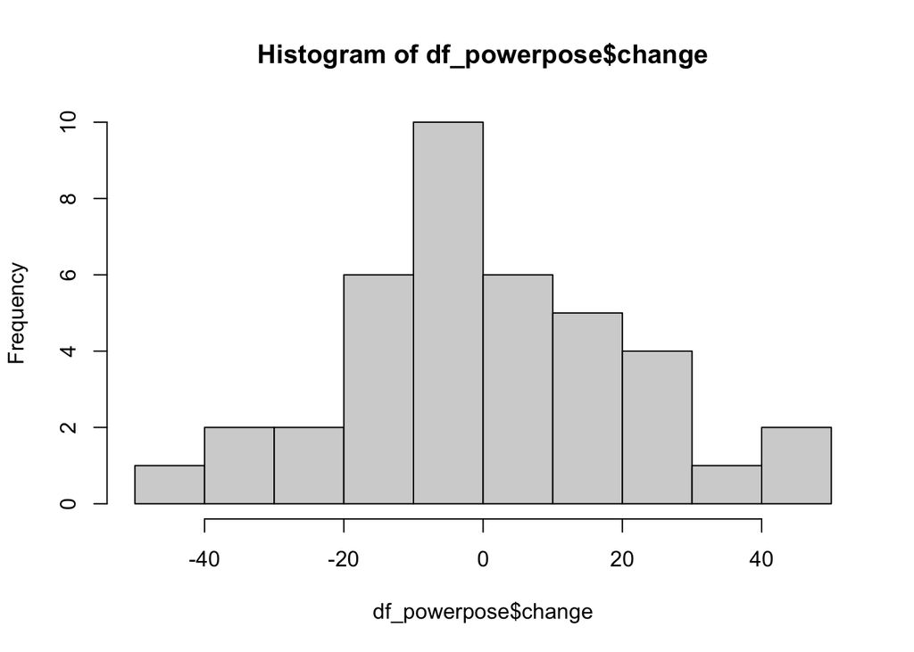

```r
# eyeball DV distribution
hist(df_powerpose$change)
```

```r
# order factor
df_powerpose$hptreat <- factor(df_powerpose$hptreat, levels = c("Low", "High"))
levels(df_powerpose$hptreat)
```

```
[1] "Low"  "High"
```

```r
# set contrasts
contrasts(df_powerpose$hptreat) <- c(-0.5,+0.5)
contrasts(df_powerpose$hptreat)
```

```
     [,1]
Low  -0.5
High  0.5
```

```r
# fit model
fit_powerpose <- brm(
  change ~ 1 + hptreat,
  data = df_powerpose,
  family = gaussian()
)
```

[output not shown]

```r
# inspect model
fit_powerpose
```

```
 Family: gaussian
  Links: mu = identity; sigma = identity
Formula: change ~ 1 + hptreat
   Data: df_powerpose (Number of observations: 39)
  Draws: 4 chains, each with iter = 2000; warmup = 1000; thin = 1;
         total post-warmup draws = 4000

Population-Level Effects:
          Estimate Est.Error l-95% CI u-95% CI Rhat Bulk_ESS Tail_ESS
Intercept    -0.01      3.29    -6.64     6.45 1.00     3681     2408
hptreat1      8.86      6.64    -4.27    21.97 1.00     3501     2645

Family Specific Parameters:
      Estimate Est.Error l-95% CI u-95% CI Rhat Bulk_ESS Tail_ESS
sigma    20.51      2.40    16.44    25.74 1.00     3562     2892

Draws were sampled using sampling(NUTS). For each parameter, Bulk_ESS
and Tail_ESS are effective sample size measures, and Rhat is the potential
scale reduction factor on split chains (at convergence, Rhat = 1).
```

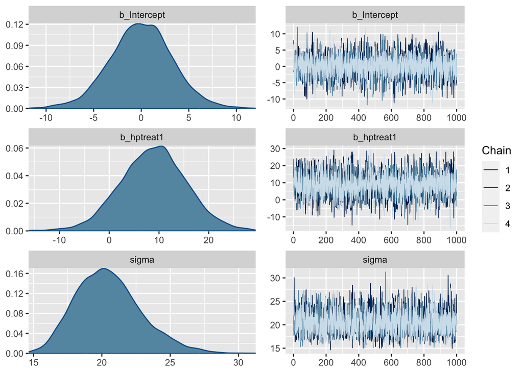

```r
plot(fit_powerpose)
```

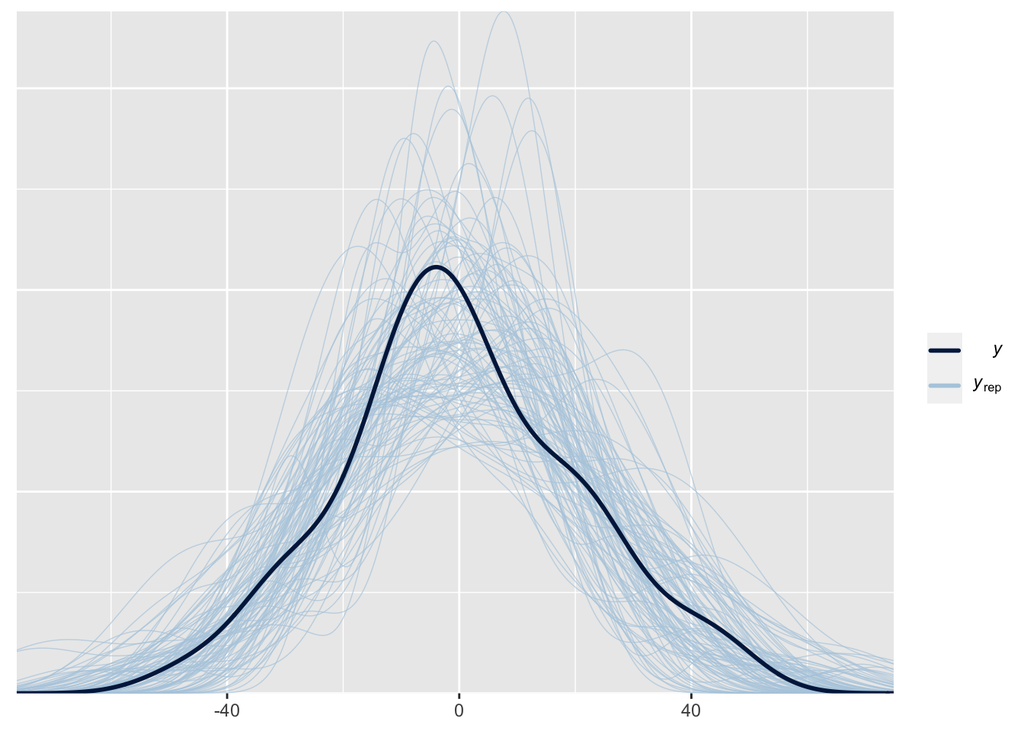

```r
pp_check(fit_powerpose, ndraws=100)
```

**My answer**

The mean posterior effect for testosterone level change is 8.86, with 95% CrI [-4.27, 21.97]. Because the effect is positive (and we set our contrasts to `Low` = `-0.5`, `High` = `+0.5`), this reflects an increase in testosterone level in the high powerpose condition (compared to low powerpose). However, the 95% CrI include 0, so we can’t conclude the effect is reliable.

## Exercise 4.2 - Another linear regression model: Revisiting attentional load effect on pupil size.

Here, we revisit the analysis shown in the chapter, on how attentional load affects pupil size.

1. Our priors for this experiment were quite arbitrary. How do the prior predictive distributions look like? Do they make sense?
2. Is our posterior distribution sensitive to the priors that we selected? Perform a sensitivity analysis to find out whether the posterior is affected by our choice of prior for the $sigma$.
3. Our data set includes also a column that indicates the trial number. Could it be that trial has also an effect on the pupil size? As in `lm`, we indicate another main effect with a `+` sign. How would you communicate the new results?

### My work

Re-load data

```r
# load data
data("df_pupil_pilot")
# centre IV
df_pupil <- df_pupil %>%
    mutate(c_load = load - mean(load))
```

#### a. Prior predictive distributions

Run prior predictive check

```r
fit_pupil_prior <- brm(
  p_size ~ 1 + c_load,
  data = df_pupil,
  family = gaussian(),
  prior = c(
    prior(normal(1000, 500), class = Intercept),
    prior(normal(0, 1000), class = sigma),
    prior(normal(0, 100),
          class = b, coef = c_load)
  ),
    sample_prior = "only",
    # PRIOR PRED DISTR
    control = list(adapt_delta = .9)
)
```

[output not shown]

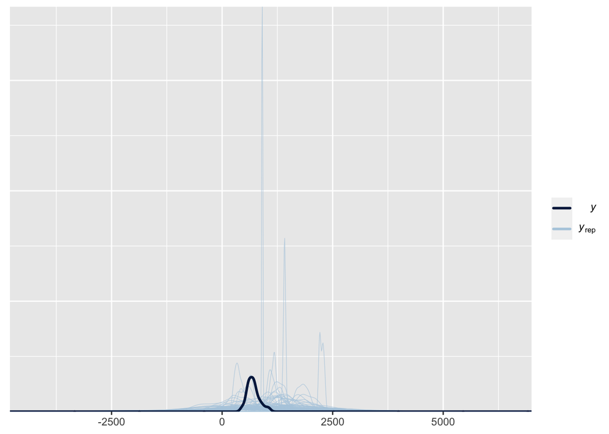

```r
pp_check(fit_pupil_prior, ndraws=100)
```

**My answer**

No our priors don’t make sense because there are negative pupil sizes.

#### b. Sensitivity analysis

Re-run model

```r
# run model
fit_pupil <- brm(p_size ~ 1 + c_load,
                 data = df_pupil,
                 family = gaussian(),
                 prior = c(
                   prior(normal(1000,500), class = Intercept),
                   prior(normal(0,1000), class = sigma),
                   prior(normal(0,100),
                         class = b, coef = c_load) # predictor prior
                 )
                 )
```

[output not shown]

```r
# 95% CrI?
as_draws_df(fit_pupil)$b_Intercept %>%
  quantile(c(0.025, 0.975))
```

```
    2.5%    97.5%
662.6490 742.4201
```

```r
# run model
fit_pupil_prin <- brm(p_size ~ 1 + c_load,
                 data = df_pupil,
                 family = gaussian(),
                 prior = c(
                   prior(normal(300,200), class = Intercept),
                   prior(normal(0,100), class = sigma),
                   prior(normal(0,100),
                         class = b, coef = c_load) # predictor prior
                 )
                 )
```

[output not shown]

```r
# 95% CrI?
as_draws_df(fit_pupil_prin)$b_Intercept %>%
  quantile(c(0.025, 0.975))
```

```
    2.5%    97.5%
662.3411 734.2754
```

**My answer**

#### c. Covariate

Add trial covariate (centre it first).

```r
df_pupil <- df_pupil %>%
  mutate(c_trial = trial-mean(trial))
```

```r
# run model
fit_pupil <- brm(p_size ~ 1 + c_load + c_trial,
                 data = df_pupil,
                 family = gaussian(),
                 prior = c(
                   prior(normal(1000,500), class = Intercept),
                   prior(normal(0,1000), class = sigma),
                   prior(normal(0,100),
                         class = b) # predictor prior
                 )
                 )
```

[output not shown]

**My answer**

## Exercise 4.3 - Log-normal model: Revisiting the effect of trial on finger tapping times

*We continue considering the effect of trial on finger tapping times.*

*a. Estimate the slowdown in milliseconds between the last two times the subject pressed the space bar in the experiment.* *b. How would you change your model (keeping the log-normal likelihood) so that it includes centered log-transformed trial numbers or square-root-transformed trial numbers (instead of centered trial numbers)? Does the effect in milliseconds change?*

### My work

Load data and centre predictor.

```r
df_spacebar <- df_spacebar %>%
  mutate(c_trial = trial - mean(trial)) %>%
  rename(rt = t)
```

Re-run `fit_press_trial` model.

```r
fit_press_trial <- brm(rt ~ 1 + c_trial,
  data = df_spacebar,
  family = lognormal(),
  prior = c(
    prior(normal(6, 1.5), class = Intercept),
    prior(normal(0, 1), class = sigma),
    prior(normal(0, .01), class = b, coef = c_trial)
  )
)
```

[output not shown]

#### a. Last two trials

Find difference in estimates between $trial_n$ and $trial_{n-1}$

```r
alpha_samples <- as_draws_df(fit_press_trial)$b_Intercept
beta_samples <- as_draws_df(fit_press_trial)$b_c_trial
last_trial <- df_spacebar$c_trial %>% max()
effect_end_ms <- exp(alpha_samples + last_trial * beta_samples) -
exp(alpha_samples + (last_trial - 1) * beta_samples)
c(mean = mean(effect_end_ms), quantile(effect_end_ms, c(.025, .975)))
```

```
      mean       2.5%      97.5%
0.09623843 0.07259868 0.12141904
```

**My answer**

The estimated slowdown (in milliseconds) between the last two trials is 0.096ms [95% CrI: 0.07,0.12].

#### b. centered log-transformed or square-root-transformed trial numbers

Create new predictors

```r
df_spacebar <- df_spacebar %>%
  mutate(
    c_log_trial = log(trial) - mean(log(trial)),
    c_sqrt_trial = sqrt(trial) - mean(sqrt(trial))
  )
```

Fit model with centred log trial.

```r
fit_press_log_trial <- brm(
  rt ~ 1 + c_log_trial,
  data = df_spacebar,
  family = lognormal(),
  prior = c(
    prior(normal(6, 1.5), class = Intercept),
    prior(normal(0, 1), class = sigma),
    prior(normal(0, 1), class = b, coef = c_log_trial)
  )
)
```

[output not shown]

What’s the difference between the first 2, middle 2, and last 2 trials?

```r
alpha_samples <- as_draws_df(fit_press_log_trial)$b_Intercept
beta_samples <- as_draws_df(fit_press_log_trial)$b_c_log_trial

# first trials
first_trial <- df_spacebar$c_trial %>% min()
effect_first_log_trial_ms <- exp(alpha_samples + first_trial * beta_samples) -
exp(alpha_samples + (first_trial + 1) * beta_samples)
c(mean = mean(effect_first_log_trial_ms), quantile(effect_first_log_trial_ms, c(.025, .975)))
```

```
          mean           2.5%          97.5%
-0.00025370085 -0.00115560440 -0.00001601707
```

```r
# middle-1 and middle trial
middle_log <- df_spacebar %>%
filter(c_trial == 0) %>%
pull(c_log_trial)
## in base R this would be <- df_spacebar[c_trial == 0]$c_log_trial
middle_m1_log <- df_spacebar %>%
filter(c_trial == -1) %>%
pull(c_log_trial)
# effect?
effect_middle_log_trial_ms <- exp(alpha_samples + middle_log * beta_samples) -
exp(alpha_samples + middle_m1_log * beta_samples)
c(mean = mean(effect_middle_log_trial_ms), quantile(effect_middle_log_trial_ms, c(.025, .975)))
```

```
      mean       2.5%      97.5%
0.05884810 0.04649987 0.07158364
```

```r
# last trial
last_trial <- df_spacebar$c_trial %>% max()
effect_end_log_trial_ms <- exp(alpha_samples + last_trial * beta_samples) -
exp(alpha_samples + (last_trial - 1) * beta_samples)
c(mean = mean(effect_end_log_trial_ms), quantile(effect_end_log_trial_ms, c(.025, .975)))
```

```
       mean        2.5%       97.5%
 1800018.75    58811.23 10131092.50
```

Fit model with centred squareroot trial.

```r
fit_press_sqrt_trial <- brm(
  rt ~ 1 + c_sqrt_trial,
  data = df_spacebar,
  family = lognormal(),
  prior = c(
    prior(normal(6, 1.5), class = Intercept),
    prior(normal(0, 1), class = sigma),
    prior(normal(0, 1), class = b, coef = c_sqrt_trial)
  )
)
```

[output not shown]

What’s the difference between the first 2, middle 2, and last 2 trials?

```r
alpha_samples <- as_draws_df(fit_press_sqrt_trial)$b_Intercept
beta_samples <- as_draws_df(fit_press_sqrt_trial)$b_c_sqrt_trial

# first trials
first_trial <- df_spacebar$c_trial %>% min()
effect_first_sqrt_trial_ms <- exp(alpha_samples + first_trial * beta_samples) -
exp(alpha_samples + (first_trial + 1) * beta_samples)
c(mean = mean(effect_first_sqrt_trial_ms), quantile(effect_first_sqrt_trial_ms, c(.025, .975)))
```

```
      mean       2.5%      97.5%
-0.2086362 -0.2714040 -0.1505117
```

```r
# middle-1 and middle trial
middle_sqrt <- df_spacebar %>%
filter(c_trial == 0) %>%
pull(c_sqrt_trial)
## in base R this would be <- df_spacebar[c_trial == 0]$c_sqrt_trial
middle_m1_sqrt <- df_spacebar %>%
filter(c_trial == -1) %>%
pull(c_sqrt_trial)
# effect?
effect_middle_sqrt_trial_ms <- exp(alpha_samples + middle_sqrt * beta_samples) -
exp(alpha_samples + middle_m1_sqrt * beta_samples)
c(mean = mean(effect_middle_sqrt_trial_ms), quantile(effect_middle_sqrt_trial_ms, c(.025, .975)))
```

```
      mean       2.5%      97.5%
0.08250603 0.06425689 0.10125219
```

```r
# last trial
last_trial <- df_spacebar$c_trial %>% max()
effect_end_sqrt_trial_ms <- exp(alpha_samples + last_trial * beta_samples) -
exp(alpha_samples + (last_trial - 1) * beta_samples)
c(mean = mean(effect_end_sqrt_trial_ms), quantile(effect_end_sqrt_trial_ms, c(.025, .975)))
```

```
    mean     2.5%    97.5%
24.75083 10.86925 47.79881
```

What’s the difference between the first 2 and middle 2 trials without transforming trial?

```r
alpha_samples <- as_draws_df(fit_press_trial)$b_Intercept
beta_samples <- as_draws_df(fit_press_trial)$b_c_trial

# first trials
first_trial <- df_spacebar$c_trial %>% min()
effect_first_trial_ms <- exp(alpha_samples + first_trial * beta_samples) -
exp(alpha_samples + (first_trial + 1) * beta_samples)
c(mean = mean(effect_first_trial_ms), quantile(effect_first_trial_ms, c(.025, .975)))
```

```
       mean        2.5%       97.5%
-0.07953901 -0.09634960 -0.06275251
```

```r
# middle-1 and middle trial
middle <- df_spacebar %>%
filter(c_trial == 0) %>%
pull(c_trial)
## in base R this would be <- df_spacebar[c_trial == 0]$c_sqrt_trial
middle_m1 <- df_spacebar %>%
filter(c_trial == -1) %>%
pull(c_trial)
# effect?
effect_middle_trial_ms <- exp(alpha_samples + middle * beta_samples) -
exp(alpha_samples + middle_m1 * beta_samples)
c(mean = mean(effect_middle_trial_ms), quantile(effect_middle_trial_ms, c(.025, .975)))
```

```
      mean       2.5%      97.5%
0.08746261 0.06747016 0.10813288
```

```r
# last trial
last_trial <- df_spacebar$c_trial %>% max()
effect_end_trial_ms <- exp(alpha_samples + last_trial * beta_samples) -
exp(alpha_samples + (last_trial - 1) * beta_samples)
c(mean = mean(effect_end_trial_ms), quantile(effect_end_trial_ms, c(.025, .975)))
```

```
      mean       2.5%      97.5%
0.09623843 0.07259868 0.12141904
```

**My answer**

The effect does seem to differ as a function of the nonlinear transoformation of the predictor. This is particularly true at the first two and last two trials. There is not much change in the effect estimate for the middle trials.

| IV | first two | middle two | last two |
| --- | --- | --- | --- |
| trial | -0.08 | 0.087 | 0.096 |
| log(trial) | 0 | 0.059 | 1800018.751 |
| sqrt(trial) | -0.209 | 0.083 | 24.751 |

## Exercise 4.4 - Logistic regression: Revisiting the effect of set size on free recall.

Our data set includes also a column coded as tested that indicates the position of the queued word. (In Figure 4.13 tested would be 3). Could it be that position also has an effect on recall accuracy? How would you incorporate this in the model? (We indicate another main effect with a `+` sign).

## Exercise 4.5 - Red is the sexiest color

Load the following data set:

```r
data("df_red")
head(df_red)
```

```
   risk age red pink redorpink
8     0  19   0    0         0
9     0  25   0    0         0
10    0  20   0    0         0
11    0  20   0    0         0
14    0  20   0    0         0
15    0  18   0    0         0
```

The data set is from a study (Beall and Tracy 2013) that contains information about the color of the clothing worn (red, pink, or red or pink) when the subject (female) is at risk of becoming pregnant (is ovulating, self-reported). The broader issue being investigated is whether women wear red more often when they are ovulating (in order to attract a mate). Using logistic regressions, fit three different models to investigate whether being ovulating increases the probability of wearing (a) red, (b) pink, or (c) either pink or red. Use priors that are reasonable (in your opinion).